[figure not shown]

```python
import matplotlib.pyplot as plt
import matplotlib.image as mpimg
img=mpimg.imread("800px-Moe's_Tavern.png")
imgplot = plt.imshow(img)
plt.axis('off')
plt.show()
```

# TV Script Generation

In this project, you'll generate your own Simpsons TV scripts using RNNs. You'll be using part of the [Simpsons dataset](https://www.kaggle.com/wcukierski/the-simpsons-by-the-data) of scripts from 27 seasons. The Neural Network you'll build will generate a new TV script for a scene at [Moe's Tavern](https://simpsonswiki.com/wiki/Moe's_Tavern).

## Get the Data

The data is already provided for you. You'll be using a subset of the original dataset. It consists of only the scenes in Moe's Tavern. This doesn't include other versions of the tavern, like "Moe's Cavern", "Flaming Moe's", "Uncle Moe's Family Feed-Bag", etc..

```python
"""
DON'T MODIFY ANYTHING IN THIS CELL
"""

data_dir = './data/simpsons/moes_tavern_lines.txt'
text = helper.load_data(data_dir)
# Ignore notice, since we don't use it for analysing the data
text = text[81:]
```

## Explore the Data

Play around with `view_sentence_range` to view different parts of the data.

```python
view_sentence_range = (90, 100)

"""
DON'T MODIFY ANYTHING IN THIS CELL
"""
import numpy as np

print('Dataset Stats')
print('Roughly the number of unique words: {}'.format(len({word: None for word in text.split()})))
scenes = text.split('\n\n')
print('Number of scenes: {}'.format(len(scenes)))
sentence_count_scene = [scene.count('\n') for scene in scenes]
print('Average number of sentences in each scene: {}'.format(np.average(sentence_count_scene)))

sentences = [sentence for scene in scenes for sentence in scene.split('\n')]
print('Number of lines: {}'.format(len(sentences)))
word_count_sentence = [len(sentence.split()) for sentence in sentences]
print('Average number of words in each line: {}'.format(np.average(word_count_sentence)))

print()
print('The sentences {} to {}:'.format(*view_sentence_range))
print('\n'.join(text.split('\n')[view_sentence_range[0]:view_sentence_range[1]]))
```

```
Dataset Stats
Roughly the number of unique words: 11492
Number of scenes: 262
Average number of sentences in each scene: 15.251908396946565
Number of lines: 4258
Average number of words in each line: 11.50164396430249

The sentences 90 to 100:
Moe_Szyslak: Oh. Here we are.
Moe_Szyslak: It's not without its charm.
Homer_Simpson: Try lighting it on fire.
Moe_Szyslak: (SMILING) Whoa! Homer, it's like there's a party in my mouth and everyone's invited.
Larry: Hey, your Love Tester's busted. I want my nickel back. (COUGHS)
Moe_Szyslak: Hey, buddy. Have one on the house.
Larry: Hey, hey, this drink is delicious! And my phlegm feels looser. What do you call it?
Homer_Simpson: Well, it's called a "Flaming...
Moe_Szyslak: Moe! It's called a "Flaming Moe"! That's right, a "Flaming Moe". My name is Moe, and I invented it. That's why it's called a Flaming Moe. What? What are you lookin' at, Homer? It's a Flaming Moe I'm Moe.
Barney_Gumble: Hey, what's this?
```

## Implement Preprocessing Functions

The first thing to do to any dataset is preprocessing. Implement the following preprocessing functions below:

- Lookup Table
- Tokenize Punctuation

### Lookup Table

To create a word embedding, you first need to transform the words to ids. In this function, create two dictionaries:

- Dictionary to go from the words to an id, we'll call `vocab_to_int`
- Dictionary to go from the id to word, we'll call `int_to_vocab`

Return these dictionaries in the following tuple `(vocab_to_int, int_to_vocab)`

```python
import numpy as np
import problem_unittests as tests
from collections import Counter

def create_lookup_tables(text):
    """
    Create lookup tables for vocabulary
    :param text: The text of tv scripts split into words
    :return: A tuple of dicts (vocab_to_int, int_to_vocab)
    """
    # TODO: Implement Function
    word_counter = Counter(text)
    vocab = sorted(word_counter, key = word_counter.get, reverse = True)
    vocab_to_int = {word: number for number, word in enumerate(vocab)}

    int_to_vocab = {number: word for word, number in vocab_to_int.items()}
    test_word = text[6]
    print(vocab_to_int[test_word])
    print(int_to_vocab[vocab_to_int[test_word]])
    return vocab_to_int, int_to_vocab


"""
DON'T MODIFY ANYTHING IN THIS CELL THAT IS BELOW THIS LINE
"""
tests.test_create_lookup_tables(create_lookup_tables)
```

```
31
meet
Tests Passed
```

### Tokenize Punctuation

We'll be splitting the script into a word array using spaces as delimiters. However, punctuations like periods and exclamation marks make it hard for the neural network to distinguish between the word "bye" and "bye!".

Implement the function `token_lookup` to return a dict that will be used to tokenize symbols like "!" into "||Exclamation_Mark||". Create a dictionary for the following symbols where the symbol is the key and value is the token:

- Period ( . )
- Comma ( , )
- Quotation Mark ( " )
- Semicolon ( ; )
- Exclamation mark ( ! )
- Question mark ( ? )
- Left Parentheses ( ( )
- Right Parentheses ( ) )
- Dash ( -- )
- Return ( \n )

This dictionary will be used to token the symbols and add the delimiter (space) around it. This separates the symbols as it's own word, making it easier for the neural network to predict on the next word. Make sure you don't use a token that could be confused as a word. Instead of using the token "dash", try using something like "||dash||".

```python
def token_lookup():
    """
    Generate a dict to turn punctuation into a token.
    :return: Tokenize dictionary where the key is the punctuation and the value is the token
    """
    # TODO: Implement Function
    tokens_dict = {'.': '||Period||'
                   , ',': '||Comma||'
                   , '"': '||Quotation_Mark||'
                   , ';': '||Semicolon||'
                   , '!': '||Exclamation_Mark||'
                   , '?': '||Question_Mark||'
                   , '(': '||Left_Parentheses||'
                   , ')': '||Right_Parentheses||'
                   , '--': '||Dash||'
                   , '\n': '||Return||'}
#                    , ':': '||Colon||'}
    return tokens_dict

"""
DON'T MODIFY ANYTHING IN THIS CELL THAT IS BELOW THIS LINE
"""
tests.test_tokenize(token_lookup)
```

```
Tests Passed
```

## Preprocess all the data and save it

Running the code cell below will preprocess all the data and save it to file.

```python
"""
DON'T MODIFY ANYTHING IN THIS CELL
"""
# Preprocess Training, Validation, and Testing Data
helper.preprocess_and_save_data(data_dir, token_lookup, create_lookup_tables)
```

```
175
moe's
```

# Check Point

This is your first checkpoint. If you ever decide to come back to this notebook or have to restart the notebook, you can start from here. The preprocessed data has been saved to disk.

```python
"""
DON'T MODIFY ANYTHING IN THIS CELL
"""
import helper
import numpy as np
import problem_unittests as tests

int_text, vocab_to_int, int_to_vocab, token_dict = helper.load_preprocess()
```

## Build the Neural Network

You'll build the components necessary to build a RNN by implementing the following functions below:

- get_inputs
- get_init_cell
- get_embed
- build_rnn
- build_nn
- get_batches

### Check the Version of TensorFlow and Access to GPU

```python
"""
DON'T MODIFY ANYTHING IN THIS CELL
"""
from distutils.version import LooseVersion
import warnings
import tensorflow as tf

# Check TensorFlow Version
assert LooseVersion(tf.__version__) >= LooseVersion('1.0'), 'Please use TensorFlow version 1.0 or newer'
print('TensorFlow Version: {}'.format(tf.__version__))

# Check for a GPU
if not tf.test.gpu_device_name():
    warnings.warn('No GPU found. Please use a GPU to train your neural network.')
else:
    print('Default GPU Device: {}'.format(tf.test.gpu_device_name()))
```

```
TensorFlow Version: 1.0.0
Default GPU Device: /gpu:0
```

### Input

Implement the `get_inputs()` function to create TF Placeholders for the Neural Network. It should create the following placeholders:

- Input text placeholder named "input" using the [TF Placeholder](https://www.tensorflow.org/api_docs/python/tf/placeholder) `name` parameter.
- Targets placeholder
- Learning Rate placeholder

Return the placeholders in the following tuple `(Input, Targets, LearningRate)`

```python
def get_inputs():
    """
    Create TF Placeholders for input, targets, and learning rate.
    :return: Tuple (input, targets, learning rate)
    """
    # TODO: Implement Function
    inputs = tf.placeholder(tf.int32, [None, None], name= 'input')
    targets = tf.placeholder(tf.int32, [None, None], name= 'targers')
    learning_rate = tf.placeholder(tf.float32, shape=(),name='placeholder')
    return inputs, targets, learning_rate


"""
DON'T MODIFY ANYTHING IN THIS CELL THAT IS BELOW THIS LINE
"""
tests.test_get_inputs(get_inputs)
```

```
Tests Passed
```

### Build RNN Cell and Initialize

Stack one or more [`BasicLSTMCells`](https://www.tensorflow.org/api_docs/python/tf/contrib/rnn/BasicLSTMCell) in a [`MultiRNNCell`](https://www.tensorflow.org/api_docs/python/tf/contrib/rnn/MultiRNNCell).

- The Rnn size should be set using `rnn_size`
- Initalize Cell State using the MultiRNNCell's [`zero_state()`](https://www.tensorflow.org/api_docs/python/tf/contrib/rnn/MultiRNNCell#zero_state) function
  - Apply the name "initial_state" to the initial state using [`tf.identity()`](https://www.tensorflow.org/api_docs/python/tf/identity)

Return the cell and initial state in the following tuple `(Cell, InitialState)`

```python
def get_init_cell(batch_size, rnn_size):
    """
    Create an RNN Cell and initialize it.
    :param batch_size: Size of batches
    :param rnn_size: Size of RNNs
    :return: Tuple (cell, initialize state)
    """
    # TODO: Implement Function

    # My LSTM model parameters
    keep_prob = 0.80 # Dropout keep probability
    lstm_layers = 1 # 1layers

    # LSTM cell definition
    lstm = tf.contrib.rnn.BasicLSTMCell(rnn_size)

    # Applying Dropout with wrapping the LSTM with Dropout wrapper with 0.75 keep probability
    drop = tf.contrib.rnn.DropoutWrapper(lstm, output_keep_prob= keep_prob)

    cell = tf.contrib.rnn.MultiRNNCell([drop] * lstm_layers)
    initial_state = tf.identity(cell.zero_state(batch_size, tf.float32), name="initial_state")
    return cell, initial_state


"""
DON'T MODIFY ANYTHING IN THIS CELL THAT IS BELOW THIS LINE
"""
tests.test_get_init_cell(get_init_cell)
```

```
Tests Passed
```

### Word Embedding

Apply embedding to `input_data` using TensorFlow. Return the embedded sequence.

```python
def get_embed(input_data, vocab_size, embed_dim):
    """
    Create embedding for <input_data>.
    :param input_data: TF placeholder for text input.
    :param vocab_size: Number of words in vocabulary.
    :param embed_dim: Number of embedding dimensions
    :return: Embedded input.
    """
    # Creating the embadding matrix
    embedding = tf.Variable(tf.random_uniform((vocab_size, embed_dim), -1, 1))
    # Looking up the word and getting the corresponding embeding from embeddings
    embed = tf.nn.embedding_lookup(embedding, input_data)
    return embed


"""
DON'T MODIFY ANYTHING IN THIS CELL THAT IS BELOW THIS LINE
"""
tests.test_get_embed(get_embed)
```

```
Tests Passed
```

### Build RNN

You created a RNN Cell in the `get_init_cell()` function. Time to use the cell to create a RNN.

- Build the RNN using the [`tf.nn.dynamic_rnn()`](https://www.tensorflow.org/api_docs/python/tf/nn/dynamic_rnn)
  - Apply the name "final_state" to the final state using [`tf.identity()`](https://www.tensorflow.org/api_docs/python/tf/identity)

Return the outputs and final_state state in the following tuple `(Outputs, FinalState)`

```python
def build_rnn(cell, inputs):
    """
    Create a RNN using a RNN Cell
    :param cell: RNN Cell
    :param inputs: Input text data
    :return: Tuple (Outputs, Final State)
    """
    #  Applying our RNN
    outputs, f_state = tf.nn.dynamic_rnn(cell, inputs, dtype= tf.float32)
    # Adding name to out final_state tensor
    final_state = tf.identity(f_state, name ="final_state")
    return outputs, final_state


"""
DON'T MODIFY ANYTHING IN THIS CELL THAT IS BELOW THIS LINE
"""
tests.test_build_rnn(build_rnn)
```

```
Tests Passed
```

### Build the Neural Network

Apply the functions you implemented above to:

- Apply embedding to `input_data` using your `get_embed(input_data, vocab_size, embed_dim)` function.
- Build RNN using `cell` and your `build_rnn(cell, inputs)` function.
- Apply a fully connected layer with a linear activation and `vocab_size` as the number of outputs.

Return the logits and final state in the following tuple (Logits, FinalState)

```python
def build_nn(cell, rnn_size, input_data, vocab_size, embed_dim):
    """
    Build part of the neural network
    :param cell: RNN cell
    :param rnn_size: Size of rnns
    :param input_data: Input data
    :param vocab_size: Vocabulary size
    :param embed_dim: Number of embedding dimensions
    :return: Tuple (Logits, FinalState)
    """
    # TODO: Implement Function
    # get the embedded input data
    inputs = get_embed(input_data, vocab_size, embed_dim)
    # build the RNN cell
    outputs, final_state = build_rnn(cell, inputs)
    # fully connected layer
    logits = tf.contrib.layers.fully_connected(outputs, vocab_size, activation_fn= None)

    return logits, final_state


"""
DON'T MODIFY ANYTHING IN THIS CELL THAT IS BELOW THIS LINE
"""
tests.test_build_nn(build_nn)
```

```
Tests Passed
```

### Batches

Implement `get_batches` to create batches of input and targets using `int_text`. The batches should be a Numpy array with the shape `(number of batches, 2, batch size, sequence length)`. Each batch contains two elements:

- The first element is a single batch of **input** with the shape `[batch size, sequence length]`
- The second element is a single batch of **targets** with the shape `[batch size, sequence length]`

If you can't fill the last batch with enough data, drop the last batch.

For exmple, `get_batches([1, 2, 3, 4, 5, 6, 7, 8, 9, 10, 11, 12, 13, 14, 15, 16, 17, 18, 19, 20], 3, 2)` would return a Numpy array of the following:

```
[
  # First Batch
  [
    # Batch of Input
    [[ 1  2], [ 7  8], [13 14]]
    # Batch of targets
    [[ 2  3], [ 8  9], [14 15]]
  ]

  # Second Batch
  [
    # Batch of Input
    [[ 3  4], [ 9 10], [15 16]]
    # Batch of targets
    [[ 4  5], [10 11], [16 17]]
  ]

  # Third Batch
  [
    # Batch of Input
    [[ 5  6], [11 12], [17 18]]
    # Batch of targets
    [[ 6  7], [12 13], [18  1]]
  ]
]
```

Notice that the last target value in the last batch is the first input value of the first batch. In this case, `1`. This is a common technique used when creating sequence batches, although it is rather unintuitive.

```python
import random

def get_batches(int_text, batch_size, seq_length):
    """
    Return batches of input and target
    :param int_text: Text with the words replaced by their ids
    :param batch_size: The size of batch
    :param seq_length: The length of sequence
    :return: Batches as a Numpy array
    """
    # TODO: Implement Function
    n_batches = int(len(int_text) / (batch_size * seq_length))

    if len(int_text[n_batches * (batch_size - 1) : ]) < batch_size * seq_length:
         n_batches -= 1

    inputs = np.array(int_text[: n_batches * batch_size * seq_length])
    targets = np.array(int_text[1: n_batches * batch_size * seq_length + 1])

    input_batches = np.split(inputs.reshape(batch_size, -1), n_batches, 1)
    target_batches = np.split(targets.reshape(batch_size, -1), n_batches, 1)

    target_batches[n_batches - 1][batch_size - 1][seq_length - 1] = int_text[0]

    # get only full batches
#     if len(int_text[n_batches * (batch_size - 1) : ]) < batch_size:
#         n_batches -= 1
#     int_text = int_text[:n_batches*batch_size]
#     batches = np.array(n_batches, 2, batch_size, seq_length)
#     for i in range(0, len(int_text), batch_size):
#         inputs = np.array()
#         targets = np.array()
#         batch = int_text[i: i + batch_size]
#         for ii in range(len(batch)):
#             inputs.append(batch[ii])
#             targets.append(get_target(int_text, ii, seq_length))
#         batches.append((inputs, targets))

    batches = np.array(list(zip(input_batches, target_batches)))
    return batches

# def get_target(int_text, idx, seq_length):
# #     r = random.randint(1, seq_length + 1)

#     start_idx = idx - seq_length if idx - seq_length < 0 else 0
#     stop_idx = idx + seq_length if idx + seq_length > len(int_text) else len(int_text) - 1

# #     target_words = set(words[start:idx] + words[idx+1:stop+1])
#     target_words = set(int_text[start_idx:idx] + int_text[idx + 1 : stop_idx + 1])

#     return target_words
"""
DON'T MODIFY ANYTHING IN THIS CELL THAT IS BELOW THIS LINE
"""
tests.test_get_batches(get_batches)
print( get_batches([1, 2, 3, 4, 5, 6, 7, 8, 9, 10, 11, 12, 13, 14, 15, 16, 17, 18, 19, 20], 3, 2) )
```

```
Tests Passed
[[[[ 1  2]
   [ 7  8]
   [13 14]]

  [[ 2  3]
   [ 8  9]
   [14 15]]]


 [[[ 3  4]
   [ 9 10]
   [15 16]]

  [[ 4  5]
   [10 11]
   [16 17]]]


 [[[ 5  6]
   [11 12]
   [17 18]]

  [[ 6  7]
   [12 13]
   [18  1]]]]
```

## Neural Network Training

### Hyperparameters

Tune the following parameters:

- Set `num_epochs` to the number of epochs.
- Set `batch_size` to the batch size.
- Set `rnn_size` to the size of the RNNs.
- Set `embed_dim` to the size of the embedding.
- Set `seq_length` to the length of sequence.
- Set `learning_rate` to the learning rate.
- Set `show_every_n_batches` to the number of batches the neural network should print progress.

```python
# Number of Epochs
num_epochs = 200 # ok number of epochs, doesn't really change if we increase it
# Batch Size
batch_size = 512 # GPU memory can handle it
# RNN Size
rnn_size = 220 # cause we have 262 sentences
# Embedding Dimension Size
embed_dim = 100 # half the size of the rnn, seems to be ok
# Sequence Length
seq_length = 10 # cause we have 11 avg. words per sentence
# Learning Rate
learning_rate = 0.01 # ok learning rate
# Show stats for every n number of batches
show_every_n_batches = 100

"""
DON'T MODIFY ANYTHING IN THIS CELL THAT IS BELOW THIS LINE
"""
save_dir = './save'
```

### Build the Graph

Build the graph using the neural network you implemented.

```python
"""
DON'T MODIFY ANYTHING IN THIS CELL
"""
from tensorflow.contrib import seq2seq

train_graph = tf.Graph()
with train_graph.as_default():
    vocab_size = len(int_to_vocab)
    input_text, targets, lr = get_inputs()
    input_data_shape = tf.shape(input_text)
    cell, initial_state = get_init_cell(input_data_shape[0], rnn_size)
    logits, final_state = build_nn(cell, rnn_size, input_text, vocab_size, embed_dim)

    # Probabilities for generating words
    probs = tf.nn.softmax(logits, name='probs')

    # Loss function
    cost = seq2seq.sequence_loss(
        logits,
        targets,
        tf.ones([input_data_shape[0], input_data_shape[1]]))

    # Optimizer
    optimizer = tf.train.AdamOptimizer(lr)

    # Gradient Clipping
    gradients = optimizer.compute_gradients(cost)
    capped_gradients = [(tf.clip_by_value(grad, -1., 1.), var) for grad, var in gradients if grad is not None]
    train_op = optimizer.apply_gradients(capped_gradients)
```

## Train

Train the neural network on the preprocessed data. If you have a hard time getting a good loss, check the [forums](https://discussions.udacity.com/) to see if anyone is having the same problem.

```python
# Show a plot of loss over epochs
def plot_loss(title, loss, plt = plt):
    """
    Plot the training loss
    """
    colors = ['r', 'b', 'g', 'c', 'y', 'k']
    label_accs = []
    label_loss = []

    plt.plot(loss, colors[0], label="Training Loss")
    plt.title(title)
    plt.xlabel('Epochs')
    plt.ylabel('Loss')
    plt.legend(bbox_to_anchor=(1.05, 1), loc=2, borderaxespad=0.)
    plt.show()
```

```python
"""
DON'T MODIFY ANYTHING IN THIS CELL
"""

batches = get_batches(int_text, batch_size, seq_length)
loss_data = []
with tf.Session(graph=train_graph) as sess:
    sess.run(tf.global_variables_initializer())

    for epoch_i in range(num_epochs):
        state = sess.run(initial_state, {input_text: batches[0][0]})

        for batch_i, (x, y) in enumerate(batches):
            feed = {
                input_text: x,
                targets: y,
                initial_state: state,
                lr: learning_rate}
            train_loss, state, _ = sess.run([cost, final_state, train_op], feed)
            loss_data.append(train_loss)
            # Show every <show_every_n_batches> batches
            if (epoch_i * len(batches) + batch_i) % show_every_n_batches == 0:
                print('Epoch {:>3} Batch {:>4}/{}   train_loss = {:.3f}'.format(
                    epoch_i,
                    batch_i,
                    len(batches),
                    train_loss))



    # Save Model
    saver = tf.train.Saver()
    saver.save(sess, save_dir)
    print('Model Trained and Saved')
```

```
Epoch   0 Batch    0/13   train_loss = 8.822
Epoch   7 Batch    9/13   train_loss = 3.888
Epoch  15 Batch    5/13   train_loss = 2.904
Epoch  23 Batch    1/13   train_loss = 2.282
Epoch  30 Batch   10/13   train_loss = 1.902
Epoch  38 Batch    6/13   train_loss = 1.604
Epoch  46 Batch    2/13   train_loss = 1.397
Epoch  53 Batch   11/13   train_loss = 1.230
Epoch  61 Batch    7/13   train_loss = 1.053
Epoch  69 Batch    3/13   train_loss = 0.967
Epoch  76 Batch   12/13   train_loss = 0.914
Epoch  84 Batch    8/13   train_loss = 0.867
Epoch  92 Batch    4/13   train_loss = 0.836
Epoch 100 Batch    0/13   train_loss = 0.735
Epoch 107 Batch    9/13   train_loss = 0.773
Epoch 115 Batch    5/13   train_loss = 0.726
Epoch 123 Batch    1/13   train_loss = 0.706
Epoch 130 Batch   10/13   train_loss = 0.634
Epoch 138 Batch    6/13   train_loss = 0.623
Epoch 146 Batch    2/13   train_loss = 0.599
Epoch 153 Batch   11/13   train_loss = 0.611
Epoch 161 Batch    7/13   train_loss = 0.604
Epoch 169 Batch    3/13   train_loss = 0.590
Epoch 176 Batch   12/13   train_loss = 0.590
Epoch 184 Batch    8/13   train_loss = 0.624
Epoch 192 Batch    4/13   train_loss = 0.629
Model Trained and Saved
```

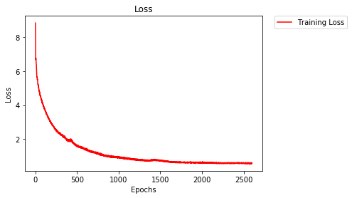

```python
plot_loss("Loss", loss_data, plt)
```

## Save Parameters

Save `seq_length` and `save_dir` for generating a new TV script.

```python
"""
DON'T MODIFY ANYTHING IN THIS CELL
"""
# Save parameters for checkpoint
helper.save_params((seq_length, save_dir))
```

# Checkpoint

```python
"""
DON'T MODIFY ANYTHING IN THIS CELL
"""
import tensorflow as tf
import numpy as np
import helper
import problem_unittests as tests

_, vocab_to_int, int_to_vocab, token_dict = helper.load_preprocess()
seq_length, load_dir = helper.load_params()
```

## Implement Generate Functions

### Get Tensors

Get tensors from `loaded_graph` using the function [`get_tensor_by_name()`](https://www.tensorflow.org/api_docs/python/tf/Graph#get_tensor_by_name). Get the tensors using the following names:

- "input:0"
- "initial_state:0"
- "final_state:0"
- "probs:0"

Return the tensors in the following tuple `(InputTensor, InitialStateTensor, FinalStateTensor, ProbsTensor)`

```python
def get_tensors(loaded_graph):
    """
    Get input, initial state, final state, and probabilities tensor from <loaded_graph>
    :param loaded_graph: TensorFlow graph loaded from file
    :return: Tuple (InputTensor, InitialStateTensor, FinalStateTensor, ProbsTensor)
    """
    # TODO: Implement Function
    input = loaded_graph.get_tensor_by_name(name='input:0')
    initial_state =  loaded_graph.get_tensor_by_name(name='initial_state:0')
    final_state = loaded_graph.get_tensor_by_name(name='final_state:0')
    probs = loaded_graph.get_tensor_by_name(name='probs:0')
    return input, initial_state, final_state, probs

"""
DON'T MODIFY ANYTHING IN THIS CELL THAT IS BELOW THIS LINE
"""
tests.test_get_tensors(get_tensors)
```

```
Tests Passed
```

### Choose Word

Implement the `pick_word()` function to select the next word using `probabilities`.

```python
def pick_word(probabilities, int_to_vocab):
    """
    Pick the next word in the generated text
    :param probabilities: Probabilites of the next word
    :param int_to_vocab: Dictionary of word ids as the keys and words as the values
    :return: String of the predicted word
    """
    # TODO: Implement Function
    # Get word from nearest words probabilisticly
    return np.random.choice(list(int_to_vocab.values()),p=probabilities)


"""
DON'T MODIFY ANYTHING IN THIS CELL THAT IS BELOW THIS LINE
"""
tests.test_pick_word(pick_word)
```

```
Tests Passed
```

## Generate TV Script

This will generate the TV script for you. Set `gen_length` to the length of TV script you want to generate.

```python
gen_length = 200
# homer_simpson, moe_szyslak, or Barney_Gumble
prime_word = 'moe_szyslak'

"""
DON'T MODIFY ANYTHING IN THIS CELL THAT IS BELOW THIS LINE
"""
loaded_graph = tf.Graph()
with tf.Session(graph=loaded_graph) as sess:
    # Load saved model
    loader = tf.train.import_meta_graph(load_dir + '.meta')
    loader.restore(sess, load_dir)

    # Get Tensors from loaded model
    input_text, initial_state, final_state, probs = get_tensors(loaded_graph)

    # Sentences generation setup
    gen_sentences = [prime_word + ':']
    prev_state = sess.run(initial_state, {input_text: np.array([[1]])})

    # Generate sentences
    for n in range(gen_length):
        # Dynamic Input
        dyn_input = [[vocab_to_int[word] for word in gen_sentences[-seq_length:]]]
        dyn_seq_length = len(dyn_input[0])

        # Get Prediction
        probabilities, prev_state = sess.run(
            [probs, final_state],
            {input_text: dyn_input, initial_state: prev_state})

        pred_word = pick_word(probabilities[dyn_seq_length-1], int_to_vocab)

        gen_sentences.append(pred_word)

    # Remove tokens
    tv_script = ' '.join(gen_sentences)
    for key, token in token_dict.items():
        ending = ' ' if key in ['\n', '(', '"'] else ''
        tv_script = tv_script.replace(' ' + token.lower(), key)
    tv_script = tv_script.replace('\n ', '\n')
    tv_script = tv_script.replace('( ', '(')

    print(tv_script)
```

```
moe_szyslak: guys, what's a little chick.
moe_szyslak: i made some kind of" / i'm out.
moe_szyslak: me, i gotta warn ya.
moe_szyslak: just watching that's it i won't turn this joint!
homer_simpson: now, we want to get your family, huh?
professor_jonathan_frink: i very pay of yourself.
seymour_skinner: there's a way to prove it.
moe_szyslak:(in pain) oh, i'm happy!
duffman: and that's the" saint elmo's fire!
c. _montgomery_burns: at least hot, you're kinda fat!
barney_gumble: it was me!
professor_jonathan_frink: the field was developed by appealing to her back your wife!(whining) but i want you to meet mr.(sing) guys, um, couldn't drink.
moe_szyslak: plastic surgery it.
moe_szyslak:(on tape) you ain't got some lady.
moe_szyslak: that's the man who help this place for? that's the sweetest plum. you... little girls you are to feed the new numbers are. as you gonna be okay.
```

# The TV Script is Nonsensical

It's ok if the TV script doesn't make any sense. We trained on less than a megabyte of text. In order to get good results, you'll have to use a smaller vocabulary or get more data. Luckly there's more data! As we mentioned in the begging of this project, this is a subset of [another dataset](https://www.kaggle.com/wcukierski/the-simpsons-by-the-data). We didn't have you train on all the data, because that would take too long. However, you are free to train your neural network on all the data. After you complete the project, of course.

# Submitting This Project

When submitting this project, make sure to run all the cells before saving the notebook. Save the notebook file as "dlnd_tv_script_generation.ipynb" and save it as a HTML file under "File" -> "Download as". Include the "helper.py" and "problem_unittests.py" files in your submission.